# BedData Vizualisation

Jakobi Milan

2019-04-03

```
## [1] "Loading databases..."
```

```
## [1] "Loading Epic metadata ."
```

```
## [1] "Loading LUSC transcription data..."
```

```
## Setting options('download.file.method.GEOquery'='auto')
```

```
## Setting options('GEOquery.inmemory.gpl'=FALSE)
```

```
## [1] "Loading LUSC methylation data..."
```

```
## [1] "Loading superexpressed genes list..."
```

```
## * `` -> ...1
```

```
## [1] "Loading underexpressed genes list..."
```

```
## * `` -> ...1
```

```
## [1] "Loading conserved genes list..."
```

```
## * `` -> ...1
```

```
## [1] 485577    572
```

Our purpose is to analyze profile of features for LUSC cancer database.

We extracted 3 lists of features differentially methylated by using the Penda package, respectively superconserved, superdown and superup features.

Our database of methylation values used here has been obtained from The Cancer Genome Atlas (TCGA) and is based on BeadChip Illumina 450k output. It contains 485577 probes for 572 patients.

Also, is used as reference the EPIMED epic database giving probes coordinates.

# 1 Step 1 : get features indexed by probes

We are here interested on indexing probes. the following function assign probes per features using the EPIMED database as reference under the following constraints : atleast 1 probe must be around the region of interest wich is defined as [-2500,2500] around the Transcription Starting Site (TSS).

The following example uses superdown deregulated genes as features.

```r
get_features <- function(targeted_genes, study, up_str = 2500, dwn_str = 2500, nb_probe_min = 1, ...) {
  print("Creating a list of features...")
  features <- study$platform[intersect(rownames(study$platform), targeted_genes), ]

  TSS <- c()
  for (i in 1:dim(features)[1]) {
    if (features$strand[i] == "-") {
      TSS[i] <- features$tx_end[i]
    }
    else {
      TSS[i] <- features$tx_start[i]
    }
  }

  print("Indexing probe by features")

  pf_chr_colname <- "seqnames"
  pf_pos_colname <- "start"
  chrs <- unique(features[, 1])
  chrs_indexed_epic <- lapply(chrs, function(chr) {
    print(chr)
    idx <- rownames(epic)[epic[[pf_chr_colname]] %in% chr]
    ret <- epic[idx, ]
    return(ret)
  })
  names(chrs_indexed_epic) <- chrs


  feat_indexed_probes <<- epimedtools::monitored_apply(features, 1, function(gene) {

    chr <- gene[[1]]
    meth_platform <- chrs_indexed_epic[[chr]]
    tmp_probes <- dmprocr::get_probe_names(gene, meth_platform, pf_chr_colname, pf_pos_colname, up_str, dwn_str)
    sub_epic <- meth_platform[tmp_probes, c(pf_chr_colname, pf_pos_colname)]

    return(tmp_probes)
  })


  features$nb_epic_probes <- sapply(feat_indexed_probes[rownames(features)], length)
  features <- cbind(features, TSS)
  sub_features <- features[features$nb_epic_probes >= nb_probe_min, ]

  warning(paste("\n", nrow(features) - nrow(sub_features), "genes were removed due to the followings selection parameters :", "\n",
    "window downstream the TSS :", dwn_str, "\n",
    "window upstream the TSS : ", up_str, "\n",
    "Min number of probes :", nb_probe_min,
    sep = " "
  ))

  return(sub_features)
}


features = get_features(penda_superdown_deregulated, trscr_lusc, up_str = 2500, dwn_str = 2500, nb_probe_min = 1)
```

We get a list of 377 features, (starting from 381), since 4 were removed due to lack of probes under our predefined constraints. To get a proper vizualisation of our methylation profiles, we are going to split our probes into bins defined as follows :

- bin 1 : from -2500bp to -1000bp compared to the TSS.
- bin 2 : from -1000bp to -500bp compared to the TSS
- bin 3 : from -500bp to the TSS

the 3 others bins are defined symmetrically ([TSS,500],[500,1000],[1000,2500]). The following function wich is a variant of the previous one map probes according to those bins

```r
get_features_bins <- function(targeted_genes, study = trscr_lusc, up_str = 2500, dwn_str = 2500, nb_probe_min = 1, ...) { #### In my uses-case, 1 for LUAD & 2 for LUSC
  print("Creating a list of features...")
  features <- study$platform[intersect(rownames(study$platform), targeted_genes), ]




  print("Indexing probes by features and by bins")

  pf_chr_colname <- "seqnames"
  pf_pos_colname <- "start"
  chrs <- unique(features[, 1])
  chrs_indexed_epic <- lapply(chrs, function(chr) {
    print(chr)
    idx <- rownames(epic)[epic[[pf_chr_colname]] %in% chr]
    ret <- epic[idx, ]
    return(ret)
  })
  names(chrs_indexed_epic) <- chrs




  feat_indexed_probes_bin <- epimedtools::monitored_apply(features, 1, function(gene) {

    chr <- gene[[1]]
    meth_platform <- chrs_indexed_epic[[chr]]
    tmp_probes <- dmprocr::get_probe_names(gene, meth_platform, pf_chr_colname, pf_pos_colname, up_str, dwn_str)
    sub_epic <- meth_platform[tmp_probes, c(pf_chr_colname, pf_pos_colname)]

    tmp_gene <- gene
    tmp_gene[[6]] <- "+"
    if (gene[[6]] == "+") {
      tmp_gene[[2]] <- as.numeric(tmp_gene[[2]]) - 2500
    } else {
      tmp_gene[[2]] <- as.numeric(tmp_gene[[3]]) + 1000
    }
    tmp_u_bin <- 0
    tmp_d_bin <- 1500
    bin1 <- dmprocr::get_probe_names(tmp_gene, sub_epic, pf_chr_colname, pf_pos_colname, tmp_u_bin, tmp_d_bin)

    tmp_gene <- gene
    tmp_gene[[6]] <- "+"
    if (gene[[6]] == "+") {
      tmp_gene[[2]] <- as.numeric(tmp_gene[[2]]) - 1000
    } else {
      tmp_gene[[2]] <- as.numeric(tmp_gene[[3]]) + 500
    }
    tmp_u_bin <- 0
    tmp_d_bin <- 500
    bin2 <- dmprocr::get_probe_names(tmp_gene, sub_epic, pf_chr_colname, pf_pos_colname, tmp_u_bin, tmp_d_bin)

    tmp_gene <- gene
    tmp_gene[[6]] <- "+"
    if (gene[[6]] == "+") {
      tmp_gene[[2]] <- as.numeric(tmp_gene[[2]]) - 500
    } else {
      tmp_gene[[2]] <- as.numeric(tmp_gene[[3]]) + 0
    }
    tmp_u_bin <- 0
    tmp_d_bin <- 500
    bin3 <- dmprocr::get_probe_names(tmp_gene, sub_epic, pf_chr_colname, pf_pos_colname, tmp_u_bin, tmp_d_bin)

    tmp_gene <- gene
    tmp_gene[[6]] <- "+"
    if (gene[[6]] == "+") {
      tmp_gene[[2]] <- as.numeric(tmp_gene[[2]]) + 0
    } else {
      tmp_gene[[2]] <- as.numeric(tmp_gene[[3]]) - 500
    }
    tmp_u_bin <- 0
    tmp_d_bin <- 500
    bin4 <- dmprocr::get_probe_names(tmp_gene, sub_epic, pf_chr_colname, pf_pos_colname, tmp_u_bin, tmp_d_bin)

    tmp_gene <- gene
    tmp_gene[[6]] <- "+"
    if (gene[[6]] == "+") {
      tmp_gene[[2]] <- as.numeric(tmp_gene[[2]]) + 500
    } else {
      tmp_gene[[2]] <- as.numeric(tmp_gene[[3]]) - 1000
    }
    tmp_u_bin <- 0
    tmp_d_bin <- 500
    bin5 <- dmprocr::get_probe_names(tmp_gene, sub_epic, pf_chr_colname, pf_pos_colname, tmp_u_bin, tmp_d_bin)

    tmp_gene <- gene
    tmp_gene[[6]] <- "+"
    if (gene[[6]] == "+") {
      tmp_gene[[2]] <- as.numeric(tmp_gene[[2]]) + 1000
    } else {
      tmp_gene[[2]] <- as.numeric(tmp_gene[[3]]) - 2500
    }
    tmp_u_bin <- 0
    tmp_d_bin <- 1500
    bin6 <- dmprocr::get_probe_names(tmp_gene, sub_epic, pf_chr_colname, pf_pos_colname, tmp_u_bin, tmp_d_bin)


    ret <- list(sub_epic = sub_epic, bin1 = bin1, bin2 = bin2, bin3 = bin3, bin4 = bin4, bin5 = bin5, bin6 = bin6)
    return(ret)


  })



  return(feat_indexed_probes_bin)
}

feat_indexed_probes_bin = get_features_bins(penda_superdown_deregulated,index_pathology = 2,trscr_lusc, up_str = 2500, dwn_str = 2500, nb_probe_min = 1)
```

We have now a map of features with the following architecture : `feat_indexed_probes_bin$gene$bin1`

# 2 Step 2 : Getting a one level depth map

We now do want to get a one level depth map to map-reduce our data (detailled below).

```r
get_binmap <- function(feat_indexed_probes_bin = feat_indexed_probes_bin, binlist = c("bin1","bin2","bin3","bin4","bin5","bin6"))  {
  bin_indexed_probes = lapply(feat_indexed_probes_bin, function(g){
    g[binlist]
  })
  bin_indexed_probes = unlist(bin_indexed_probes, recursive = FALSE)
}

binmap = get_binmap(feat_indexed_probes_bin = feat_indexed_probes_bin, binlist = c("bin1","bin2","bin3","bin4","bin5","bin6"))
```

Our binmap is now a list of one level depth, of length bins times features (2286)

# 3 Step 3 : Map-reducing

We now do want to aggregate our data per gene by a given function (eg : mean). To do so we use the following reduce_rows function :

```r
reduce_rows <- function(tmp_meth_data, map, indicator_func2 = mean, ...) {
  dim(tmp_meth_data)
  meth_by_tissues_by_feature <- epimedtools::monitored_apply(mod = 10, t(t(names(map))), 1, function(f) {

    probe_idx <- intersect(rownames(tmp_meth_data), map[[f]])
    if (length(probe_idx) == 0) {

      tmp_meth_by_tissues_by_feature <- rep(NA, ncol(tmp_meth_data))
      names(tmp_meth_by_tissues_by_feature) <- colnames(tmp_meth_data)
    } else if (length(probe_idx) > 1) {
      tmp_meth_by_tissues_by_feature <- apply(tmp_meth_data[probe_idx, ], 2, indicator_func2, ...)
    } else {
      tmp_meth_by_tissues_by_feature <- sapply(tmp_meth_data[probe_idx, ], indicator_func2, ...)
    }
    return(tmp_meth_by_tissues_by_feature)
  })
  colnames(meth_by_tissues_by_feature) <- names(map)
  meth_by_tissues_by_feature <- t(meth_by_tissues_by_feature)
  return(meth_by_tissues_by_feature)
}

means_per_bins_per_genes_per_patient = reduce_rows(meth_lusc$data,binmap,mean,na.rm=T)
```

# 4 Step 4 : Subsetting map-reduced database.

To get a proper vizualisation, our proposal is to map-reduce a second time, aggregating values per bins, with the following function.

```r
subset_vals_per_bins <- function(values_per_patient = means_per_bins_per_genes_per_patient, binlist = c("bin1","bin2","bin3","bin4","bin5","bin6"), fun = mean, ...){
  values_per_bins <- apply(values_per_patient,1,fun, na.rm=T)
  ret <- list()

  vals <- sapply(binlist, function(bin){
    ret[[bin]] <- values_per_bins[endsWith(names(values_per_bins),bin)]
    return(ret)

    }
  )


  tmp = reduce_rows(meth_lusc$data, feat_indexed_probes, mean, na.rm=T) ### note that you need feat_indexed_probes loaded into your environnment, it should be if you follow the pipeline.
  overall = apply(tmp,1,fun,na.rm=T)


  vals_per_genes <- do.call(cbind,vals)
  vals_per_genes <- cbind(vals_per_genes,overall)
  colnames(vals_per_genes) <-c(binlist,"overall")
  rownames(vals_per_genes) <- names(feat_indexed_probes_bin)

  return(vals_per_genes)

}

means = subset_vals_per_bins(values_per_patient = means_per_bins_per_genes_per_patient)
```

We finally obtain a table ( 381*7)of the means values used ( here, mean) with features as rows and bins as columns with an additionnal column “overall”, calculated over the data without bins.

# 5 Step 5 : Vizualising using heatmap

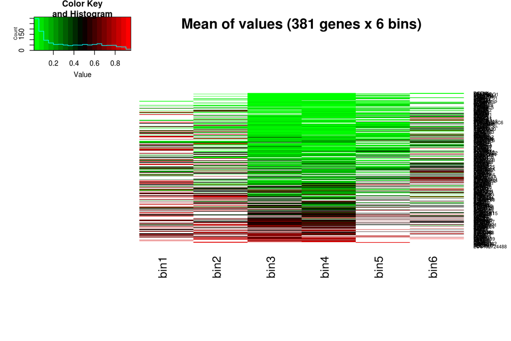

```r
meth_heatmap <- function(data = means, dendrogram = "none", Rowv = NULL, Colv = NULL, ...){

  data = data[order(data[,7]),]
  data = data[,-7]



  colors=c("green", "black", "red")
  cols = colorRampPalette(colors)(20)

  foo = gplots::heatmap.2(data, Rowv=Rowv, Colv=Colv, dendrogram=dendrogram, trace="none", col=cols, main=paste0("Mean of values (", nrow(data), " genes x ", ncol(data)," ", "bins)"), mar=c(10,5), useRaster=TRUE)

return(foo)
}

meth_heatmap(means)
```

# 6 Repeating steps 3,4,5 using variance

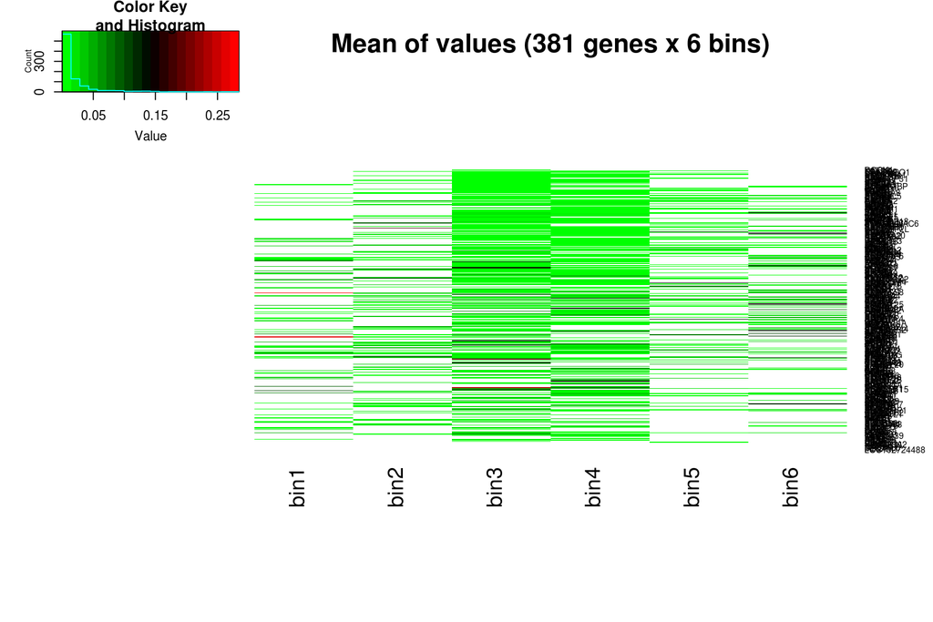

```r
vars_per_bins_per_genes_per_patient = reduce_rows(meth_lusc$data,binmap,var,na.rm=T)
vars = subset_vals_per_bins(values_per_patient = vars_per_bins_per_genes_per_patient)
meth_heatmap(vars)
```